# Introducción al análisis de datos con R y Rstudio

Melissa Alegría Arcos

# Introduccion

## Objetivos

1.- instalación del R y Rstudio Rstudio es un entorno de desarrollo integrado (IDE) que hace más fácil la manipulación de código de R.

2.- R sobre Collaboratory

3.- Primeros pasos en R.

## Instando R

[figure not shown]

Para instalar R, primero vamos a guiarnos por material externo desde [aqui](https://rubenfcasal.github.io/post/instalacion-de-r/)

1.- El primer paso es ir a descargar R, para ello hay varios mirrors, vamos a utilizar el link donde se encuentra [R desde uChile](https://cran.dcc.uchile.cl/)

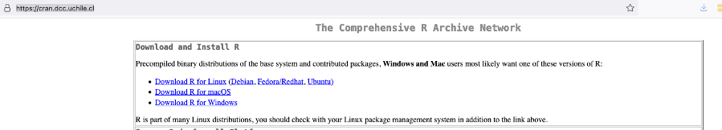

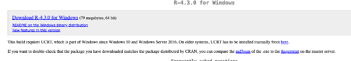

[figure not shown]

Una vez terminada la instalación, al abrir R aparece la ventana de la consola (es parecido a un terminal de Unix) que permite ejecutar comandos de R.

## Instando RStudio

[figure not shown]

Para ello no sguiaremos por este [tutorial](https://rubenfcasal.github.io/post/instalacion-de-rstudio/)

1.- [Descargar Rstudio](https://posit.co/download/rstudio-desktop/)

Al ejecutarlo deberían ver una consola de este tipo

[figure not shown]

*RStudio es un interfaz gráfica para usar R y esta disponible para todos los sistemas operativos. En otras palabras, es un entorno integrado para utilizar y programar con R

Existen 4 ventanas, en donde podemos ver el área de trabajo, el entorno, la consola y los archivos o graficos que se van generando

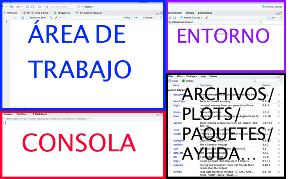

**Para Ubuntu o Linux**

1. Abrir una terminal y se instala via comando con:

`sudo aptitude install r-base`

** RStudio en Ubuntu o Linux**

1. [Obtener RStudio](http://www.rstudio.com/products/rstudio/download/)
2. Luego de descargar el .deb, abrir una terminal y colocar el siguiente comando: `sudo dpkg -i rstudio-<version>-i386.deb`

   `version` refiere ala versión concreta que se haya descargado

## Comandos de Ayuda

- `help()`: obtener ayuda por consola [mas información](https://www.r-project.org/help.html)
- `??...`: obtener ayuda por consola
- Pestaña `Help` de Rstudio
- [Cheat Sheet de RStudio](https://www.dropbox.com/s/l3uutpfz5vlujow/rstudio-ide-1.pdf?dl=0)
- Si tiene problemas de codigo recomiendo buscar en Google o en paginas como stackoverflow, R project, Kaggle, Rpubs, etc)

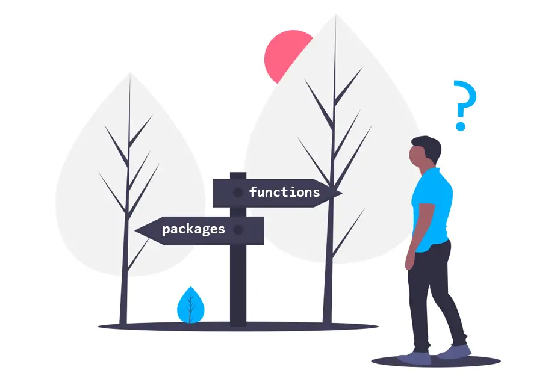

## Instalación de Paquetes

- `install.packages("nombre_paquete", dep = TRUE)`: instala o actualiza un paquete de R, con dependencias
- `library(nombre_del_paquete)`: Si ya esta instalado, este comando permite cargae un paquete

# Comenzando con R

En la consola o en el area de trabajo de RStudio podemos realizar operaciones básicas

## Operaciones aritméticas con R

| Código | Operación |
| --- | --- |
| `+` | Suma |
| `-` | Resta |
| `*` | Multiplicación |
| `/` | División |
| `^` | Potencia |
| `%/%` | Cociente entero |
| `%%` | Resto de división entera |

```r
5+2
```

```
[1] 7
```

```r
90 - 105
```

```
[1] -15
```

```r
77*5
```

```
[1] 385
```

```r
10/2
```

```
[1] 5
```

```r
10%%2
```

```
[1] 0
```

```r
#Sumatoria de los números 1 al 5
sum(1:5)
```

```
[1] 15
```

```r
#Multiplicatoria de los números 1 al 5
prod(1:5)
```

```
[1] 120
```

## Código y significado

| Código | Significado |
| --- | --- |
| `pi` | [$\pi$](https://es.wikipedia.org/wiki/Número_π) |
| `Inf` | [$\infty$](https://es.wikipedia.org/wiki/Infinito) |
| `NaN` | Indeterminación (Not a Number) |
| `NA` | Valor desconocido (Not Available) |

```r
pi
```

```
[1] 3.141593
```

## Funciones

| Código | Función |
| --- | --- |
| `sqrt(x)` | $\sqrt{x}$ |
| `exp(x)` | $e^x$ |
| `log(x)` | $\ln(x)$ |
| `log10(x)` | $\log_{10}(x)$ |
| `log(x,a)` | $\log_a(x)$ |
| `abs(x)` | $\begin{vmatrix}x\end{vmatrix}$ |

## Funciones

```r
sqrt(9)
```

```
[1] 3
```

```r
log(exp(1))
```

```
[1] 1
```

```r
log(1000,10)
```

```
[1] 3
```

```r
log10(1000)
```

```
[1] 3
```

## Operaciones y Combinatoria

| Código | Operación |
| --- | --- |
| `factorial(x)` | [$x!$](https://es.wikipedia.org/wiki/Factorial) |
| `A == a` | `FALSE` |
| `b != a` | `TRUE` |

- Número factorial. Se define como número factorial de un número entero positivo $n$ como $n!=n\cdot(n-1)\cdots 2\cdot 1$

### Factorial

```r
factorial(5)
```

```
[1] 120
```

```r
choose(4,2)
```

```
[1] 6
```

```r
factorial(6)
```

```
[1] 720
```

```r
factorial(5)*6
```

```
[1] 720
```

### Comparaciones

```r
"A" == "a"
```

```
[1] FALSE
```

```r
"b " != "b"
```

```
[1] TRUE
```

```r
"b" != "b"
```

```
[1] FALSE
```

## Trigonometría en radianes

| Código | Función |
| --- | --- |
| `sin(x)` | $\sin(x)$ |
| `cos(x)` | $\cos(x)$ |
| `tan(x)` | $\tan(x)$ |
| `asin(x)` | $\arcsin(x)$ |
| `acos(x)` | $\arccos(x)$ |
| `atan(x)` | $\arctan(x)$ |

## Trigonometría en radianes

```r
sin(pi/2)
```

```
[1] 1
```

```r
cos(pi)
```

```
[1] -1
```

```r
tan(0)
```

```
[1] 0
```

## Asignacion de nombres a objetos

Si bien se puede hacer con los operadores `=` o `<-`. En este curso utilizaremos el `<-` y el `=` los reservaremos para los parámetros de las funciones

```r
a <- 3
print(a)
```

```
[1] 3
```

```r
b = 10
print(b)
```

```
[1] 10
```

```r
c <- a*b
print(c)
```

```
[1] 30
```

## Números en coma flotante

[output not shown]

```r
print(pi,5)
```

```
[1] 3.1416
```

```r
round(pi,5)
```

```
[1] 3.14159
```

```r
floor(pi)
```

```
[1] 3
```

```r
ceiling(pi)
```

```
[1] 4
```

## Creación de vectores

```r
v1 <- c(1,24,12)
```

Utilizando [ ] se puede extraer un elemento o subconjunto de elementos de un vector

```r
v1[1]
```

```
[1] 1
```

**Nota importante: En R la numeración comienza en 1, mientras que en Python empieza en 0**

## Operaciones sobre vectores

```r
v1*3
```

```
[1]  3 72 36
```

```r
v1
```

```
[1]  1 24 12
```

```r
v2 <- v1 * 3
v2
```

```
[1]  3 72 36
```

```r
#Operaciones enre vectores de igual tamaño
v2 <- c(1, 6, 50) - c(1,-12,3.6)
v2
```

```
[1]  0.0 18.0 46.4
```

## Variables y funciones

- `nombre_variable = valor`: define una variable con dicho valor
- `nombre_función = function(variable){función}`: define una función

```r
miVariable = 4
doble = function(x){2*x}
doble(miVariable)
```

```
[1] 8
```

```r
cuadrado = function(x){x^2}
cuadrado(miVariable)
```

```
[1] 16
```

## Números complejos

| Código | Función |
| --- | --- |
| `a+bi` | [Número complejo](https://es.wikipedia.org/wiki/Número_complejo) |
| `complex(real=...,imaginary=...)` | Número complejo en forma binómica |
| `complex(modulus=...,argument=...)` | Número complejo en forma polar |

## Números complejos

| Código | Función |
| --- | --- |
| `sqrt(as.complex(-x))` | $\sqrt{-x}$ |
| `Re(x)` | Parte real de $x$ |
| `Im(x)` | Parte imaginaria de $x$ |
| `Mod(x)` | Módulo de $x$ |
| `Arg(x)` | Argumento de $x$ |
| `Conj(x)` | Conjugado de $x$ |

## Números complejos

```r
z = 2+3i
z2 = complex(real = 2, imaginary = -3)
Re(z)
```

```
[1] 2
```

```r
Im(z)
```

```
[1] 3
```

```r
Conj(z2)
```

```
[1] 2+3i
```

# Ejercicio: Hacer esto mismo en Google Colab

[Link: https://colab.to/r](https://colab.to/r)

También puede ser este link `https://colab.research.google.com/notebook#create=true&language=r`

# Tarea

Familiarizarse con R y RStudio. Deben todos tener instalado en sus computadores/laptop o usar Colab.